# R Session 1

Paul Maley

October 25, 2016

## Objectives

- Learn the basics of using R
- Illustrate the work we have done before the holidays by producing and working with distributions of sample statistics

This document is available at http://github.com

## Getting started

- Fire up RStudio …..
- We enter commands into the console (this is real programming - no clicking!).
- Try evaluating some basic arithmetic expressions
- Type the expression:

```r
1+1
```

- and hit enter to evaluate it:

```
## [1] 2
```

- Try some more:

```r
2*3 + 1
```

```
## [1] 7
```

```r
21/3
```

```
## [1] 7
```

```r
x <- 3/4
```

- Where’s `x` gone? It’s here:

```r
x
```

```
## [1] 0.75
```

- We use `<-`to bind a name to an object (a number for example). We can then use that name to refer to or reference that object

```r
x+1
```

```
## [1] 1.75
```

```r
x^2
```

```
## [1] 0.5625
```

- More than single numbers, we’ll be most interested in dealing with vectors of numbers. To create a vector we use the function `c` (c for concatenate):

```r
 xs <- c(1,2,3,4,5)
 xs
```

```
## [1] 1 2 3 4 5
```

- R has zillions (more or less) of functions, try a few out!

```r
max(xs)
```

```
## [1] 5
```

```r
min(xs)
```

```
## [1] 1
```

```r
mean(xs)
```

```
## [1] 3
```

```r
median(xs)
```

```
## [1] 3
```

```r
sd(xs)
```

```
## [1] 1.581139
```

**Exercise**

- Define a vector of numbers: `mydata <- c( ... )`
- Calculate the mean, standard deviation, median, upper and lower quartiles.
- As we go forwards we’ll introduce more functions and more ways to use R

## Visualising data

- R gives us a whole bunch functions for visualising data.
- Let’s start with `plot`. One way to visualise your data is to draw points on a number line. We can use `plot` to do that.

**Exercise**

- Use the function `rep` to produce a vector of zeros the same length as your vector `mydata` (try `help(rep)`and `help(length)`)
- With `z` as your vector of zeros do `plot(mydata, z)` (what happens if you inverse `mydata`and `z`?)
- Look at `help(plot)`and change the axis labels and the title.
- Calculate the mean of your data and add a point on the plot: `points(mymean,0)`
- Calculate the standard deviation of your data
- Add a line on your plot which starts at the mean minus one standard deviation and ends at the mean plus one standard deviation

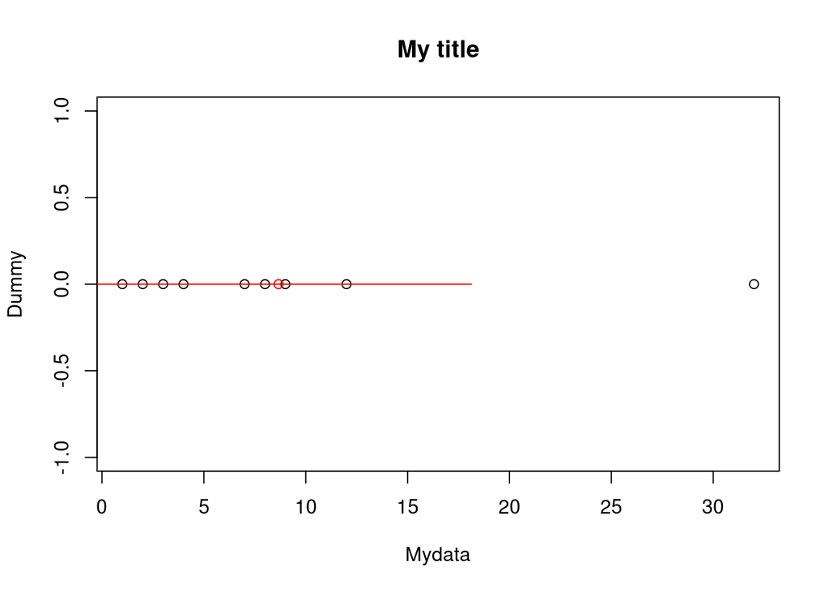

- This way of building data visuals can be useful but often there are prebuilt functions you can use.
- One that you have seen last year is the histogram. Do help `help(hist)` and make a histogram of your data.
- Another useful function is `boxplot`; give it a try (you can use `horizontal=TRUE` to rotate it).

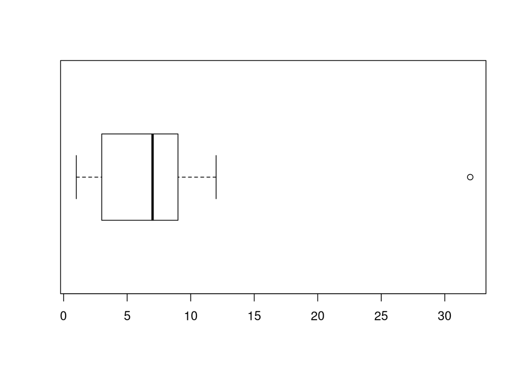

- Check that the values returned by the functions `median` and `quartile` correspond with the plot.

## Generating data

- An incredibly useful thing to be able to do is generate simulated data. We’ll not really use this in the course, but we can use it here to test our data analysis.
- We can use the function `rnorm` to produce values distributed according to the normal distribution:

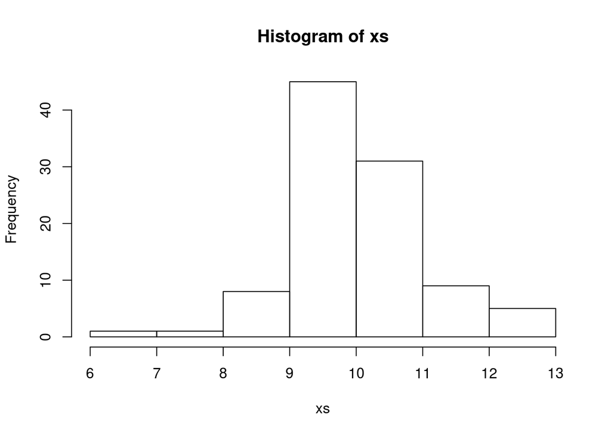

```r
xs <- rnorm(100, mean = 10, sd = 1)   # 100 values drawn from N(10,1)
hist(xs)
```

**Exercise**

Calculate a 90% confidence interval for some data sampled from a normal distribution:

- Generate a vector of ten or so values from a normal distribution with mean and standard deviation of your choice.
- Calculate the mean value of the sample
- Use the function `qnorm` (`help(qnorm)`) to calculate the value of z to use for the interval
- Use the standard deviation of the population, the sample mean, the sample size and the calculated value of z to form a confidence interval for your data.
- Plot the data along with the confidence interval.

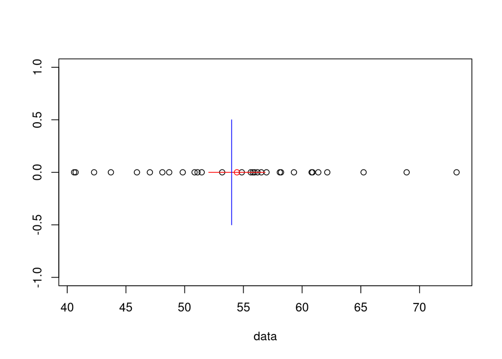

```r
popln.sigma <- 8
popln.mean <- 54
n <- 30
data <- rnorm(n, popln.mean, popln.sigma)
sample.mean <- mean(data)
z <- abs(qnorm(.05))
x.low <- sample.mean - z*popln.sigma/sqrt(n)
x.high <- sample.mean + z*popln.sigma/sqrt(n)
plot(data, rep(0,length(data)), ylab = '')
points(sample.mean, 0, col='red')
lines(c(x.low, x.high), c(0,0), col='red')
lines(c(popln.mean, popln.mean), c(-0.5,0.5), col='blue')
```

- Play around with different values of n, $\sigma$, $\mu$ and $\alpha$ and see what effect that has
- Instead of using the population standard deviation calculate the sample standard deviation and use `qt()` to calculate a confidence interval based on the Student-t distribution.

**Exercise** Use `pnorm`, `pt`, `qnorm`, and `qt` to calculate the following:

- $P(X < 2)$ where $X \sim N(3,1)$ (Normal distribution with mean 3 and standard deviation 1)
- $P(|Z| > 3)$ where $Z \sim N(0,1)$
- $P(T > 2)$ where $T$ is sampled from a t distribution with 7 degrees of freedom
- $z_c$ such that $P(Z<z_c) = 0.3$
- $t_c$ such that $P(T<t_c) = 0.8$ where $T$ is sampled from a t distribution with 12 degrees of freedom
- etc..

## Getting data into R

- We have seen vectors of values.
- Now let’s look at the workhorse of R data - the data.frame.
- A data frame is like a database table with each row corresponding to an observation and the columns contianing the values for the different variables.
- Generally we get data frames by reading in data from a file. For example:

```r
  rd <- read.csv("my_data.csv", header=TRUE)
  data <- data.frame(rd)
```

- Do `help(read.csv)` to see the details …. this can be a bit tricky sometimes!
- Once we have a data frame we can start to produce some visualisations and descriptive statistics:
- Here’s an example of what a small data frame looks like:

|  | Type | Height | Weight |
| --- | --- | --- | --- |
| 1 | A | 60.84 | 22.09 |
| 2 | B | 53.12 | 23.36 |
| 3 | B | 45.52 | 23.13 |
| 4 | A | 36.03 | 20.25 |
| 5 | A | 54.77 | 23.83 |
| 6 | B | 54.93 | 22.55 |
| 7 | A | 44.12 | 25.35 |
| 8 | B | 38.45 | 28.10 |
| 9 | B | 49.65 | 27.26 |
| 10 | B | 59.60 | 20.46 |
| 11 | B | 64.11 | 27.86 |
| 12 | B | 43.71 | 23.39 |
| 13 | A | 50.64 | 22.11 |
| 14 | A | 47.27 | 22.72 |
| 15 | A | 47.71 | 28.88 |

- We can read one row like this:

```r
 mydata[3,]
```

```
##   Type   Height   Weight
## 3    B 45.52182 23.12888
```

- Or one column like this:

```r
 mydata[,2]
```

```
##  [1] 60.83573 53.11862 45.52182 36.03355 54.77056 54.92917 44.12260
##  [8] 38.45462 49.64504 59.60033 64.11260 43.70726 50.63955 47.26579
## [15] 47.71472
```

```r
 mydata$Height
```

```
##  [1] 60.83573 53.11862 45.52182 36.03355 54.77056 54.92917 44.12260
##  [8] 38.45462 49.64504 59.60033 64.11260 43.70726 50.63955 47.26579
## [15] 47.71472
```

- These are the data structures you will work with.
- To visualise the distribution of heights:

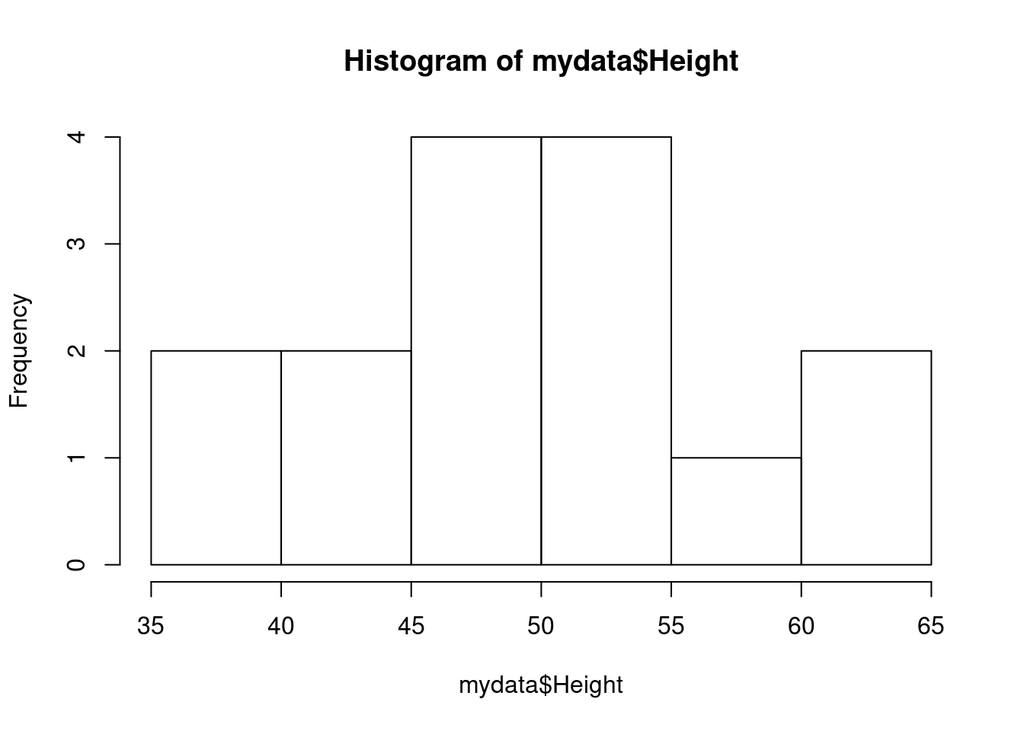

```r
  hist(mydata$Height)
```

The “$” operator returns one of the columns of the data frame.

- We can look at grouped data:

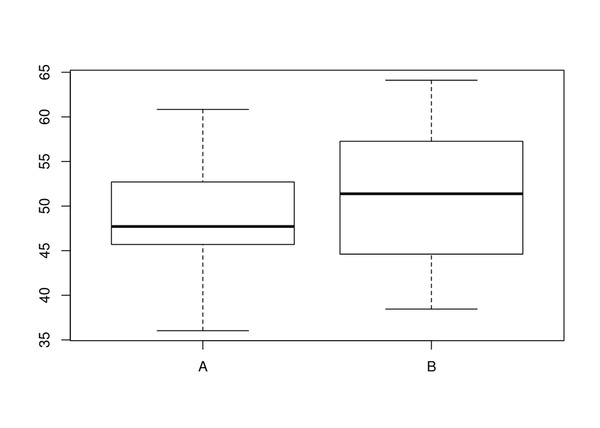

```r
 boxplot(mydata$Height~mydata$Type)
```

- We see above the use of $\sim$ in the call to `boxplot`. We’ll see it a lot more in the weeks that come where it will specify a model (dependence of a variable on other variables). Here we are using it to group the observations (rows in the data frame) according to `Type`.
- We can of course also apply functions to the data:

```r
 mean(mydata$Weight)
```

```
## [1] 24.08906
```

- Or look at plots:

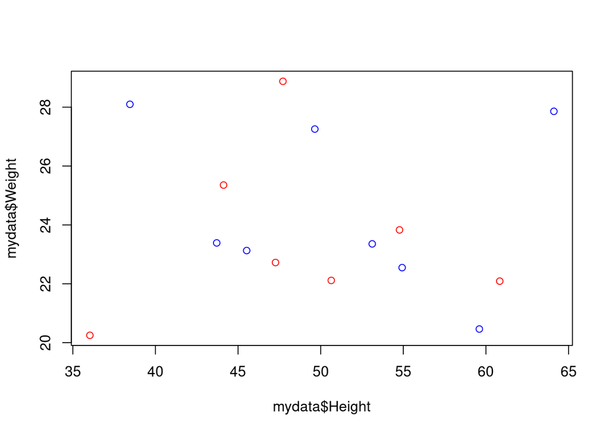

```r
 plot(mydata$Height, mydata$Weight, col = ifelse(mydata$Type=='A', 'red', 'blue'))
```

## Sampling

- Let’s start by producing some samples from a random variable: Rolling a die produces the numbers 1 to 6 with equal probability. We can use the `sample` function to model this:

```r
n <- 10
rolls <- sample(c(1,2,3,4,5,6), n, replace = TRUE)
rolls
```

```
##  [1] 3 4 1 1 1 5 1 1 5 2
```

- Repeating the function call will produce a different sample

```r
n <- 10
morerolls <- sample(c(1,2,3,4,5,6), n, replace = TRUE)
morerolls
```

```
##  [1] 3 5 5 6 3 4 5 4 5 4
```

- To see what the various arguements we pass into the function mean we can look at the `help` for a function (in Rstudio look on the right hand side in the help window):

```r
?sample
```

## Sampling errors

- For a given sample we can calculate the mean

```r
# Normal distribution with mean 1 and standard deviation 1:
n <- 10
xs <- rnorm(n, mean = 1, sd = 1)
xs
```

```
##  [1] 1.600494752 0.366001537 1.168413524 0.182161642 1.350189545
##  [6] 0.007921031 0.575842763 1.146736689 3.421884846 0.707240030
```

```r
mean(xs)
```

```
## [1] 1.052689
```

```r
sd(xs)
```

```
## [1] 0.9827139
```

- Here we see the sampling error 1.0526886-1=0.0526886
- But this is for one sample - what really interests us is how is this error distributed.

```r
## Change the value of n to set the sample size
n <- 10

## A function to produce a sample of size n
## Change mu and sigma to modify the population distribution and hence the samples
mu <- 1
sigma <- 1
makesample <- function(n) { rnorm(n, mean=mu, sd=sigma)}

# Produce a few samples and calculate their means:
sample1 <- makesample(10)
sample1
```

```
##  [1]  0.9930927  1.6467592  0.5033392  1.5047811  0.3045007  1.2869920
##  [7] -0.5122495  0.4070757  0.4880651  1.2474186
```

```r
mean(sample1)
```

```
## [1] 0.7869775
```

```r
sample2 <- makesample(10)
sample2
```

```
##  [1]  0.2094560  0.7967132 -0.3632268  1.6351927  1.4852849  0.9857328
##  [7]  1.6636679  0.1864638  1.0318606  0.6057936
```

```r
mean(sample2)
```

```
## [1] 0.8236939
```

```r
sample3 <- makesample(10)
sample3
```

```
##  [1]  0.09461803  1.12928857  0.75924792  2.03160173  2.33436779
##  [6] -0.12613601 -0.07400776 -0.92029269  2.10139862  1.92104115
```

```r
mean(sample3)
```

```
## [1] 0.9251127
```

- We can manufacture a series of samples with a bit of programming. This code produces three samples each with 5 elements.

```r
n <- 5
xbars <- lapply(rep(n, 3), function(x) {makesample(x)})
xbars
```

```
## [[1]]
## [1] 2.2838891 1.4458278 1.3594052 0.7829953 1.5497436
##
## [[2]]
## [1] 3.471195 1.162453 1.557279 1.849166 1.453990
##
## [[3]]
## [1] 1.4741184 1.0342263 1.1588110 3.1582690 0.8425402
```

- And if we are only interested in the sample means then:

```r
n <- 5
xbars <- lapply(rep(n, 3), function(x) {mean(makesample(x))})
xbars
```

```
## [[1]]
## [1] 0.7835588
##
## [[2]]
## [1] 0.6301849
##
## [[3]]
## [1] 1.82905
```

- If we produce a whole set of different samples and calculate the mean for each one what is the distribution of these mean values? This requires a bit more work!

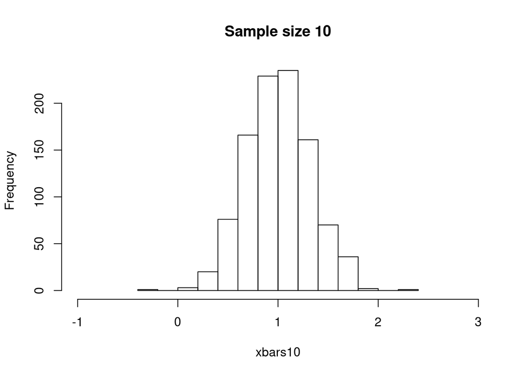

```r
# Make 1000 samples and look at the distribution of the sample means
n <- 10
xbars10 <- sapply(rep(n, 1000), function(x) {mean(makesample(x))})

# And display the distribution
hist(xbars10, main = paste0("Sample size ",n, collapse=""), xlim = c(mu-2*sigma, mu+2*sigma))
```

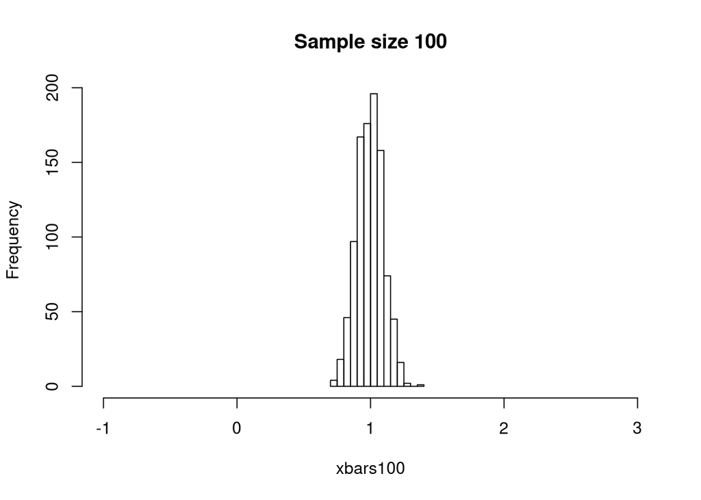

```r
n <- 100
xbars100 <- sapply(rep(n, 1000), function(x) {mean(makesample(x))})

# And display the distribution
hist(xbars100, main = paste0("Sample size ",n, collapse=""), xlim = c(mu-2*sigma, mu+2*sigma))
```

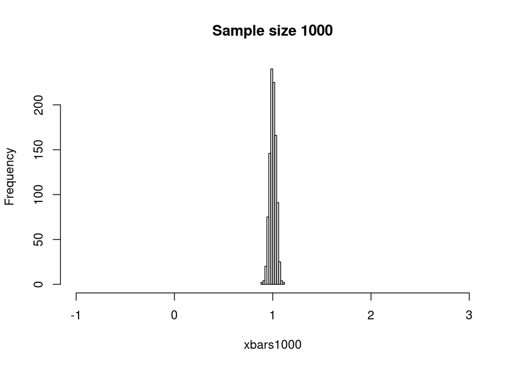

```r
n <- 1000
xbars1000 <- sapply(rep(n, 1000), function(x) {mean(makesample(x))})

# And display the distribution
hist(xbars1000, main = paste0("Sample size ",n, collapse=""), xlim = c(mu-2*sigma, mu+2*sigma))
```

- Hopefully you are convinced that the mean value of a sample is distributed around the population mean and that as the sample size increases the sample error tends to decrease.
- No?

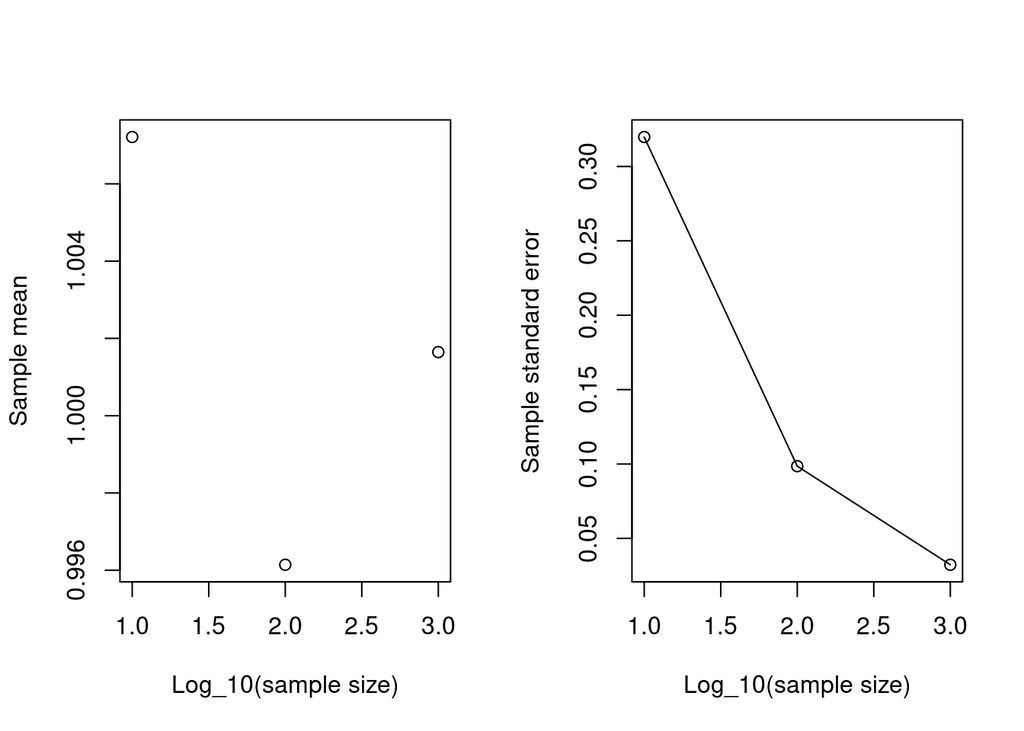

```r
means <- c(mean(xbars10), mean(xbars100), mean(xbars1000))
sds <- c(sd(xbars10), sd(xbars100), sd(xbars1000))
par(mfrow=c(1,2))
plot(means, xlab = 'Log_10(sample size)', ylab = 'Sample mean')
plot(sds, type = 'o', xlab = 'Log_10(sample size)', ylab = 'Sample standard error')
```

**Exercise** - Use the following code to do the same thing for a uniformly distributed random variable. Rerun the code snippet for increasing values of `n` and observe the distribution.

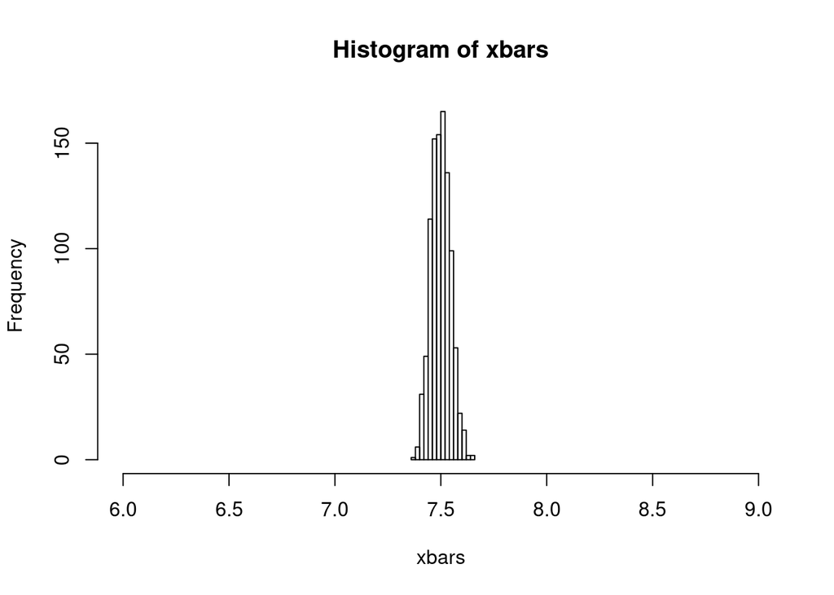

```r
g <- function(n) { runif(n, 5, 10)} # Produces random numbers in the interval [5,10]

n <- 1000
xbars <- sapply(rep(n, 1000), function(x) {mean(g(x))})
hist(xbars, xlim = c(6,9))
```